# Performance evaluation across models:

In my opinion, the best way of evaluating our model would be using out-sample multivariate normal log-likelihood.

The multivariate normal likelihood for a single observation is:

$$ \frac{1}{\sqrt{(2\pi)^d|\boldsymbol\Sigma|}} \exp\left(-\frac{1}{2}({x}-{\mu})^T{\boldsymbol\Sigma}^{-1}({x}-{\mu}) \right) $$

If we make our $\Sigma = \Sigma_t$ time-varying, taking logarithms and including n samples:

$$ l(\mu_t, \boldsymbol\Sigma_t) = -\frac{n}{2} log\left( (2 \pi)^d |\boldsymbol\Sigma_t| \right) - \frac{1}{2}\sum_{i=1}^{n} ({x_i}-{\mu_t})^T{\boldsymbol\Sigma_t}^{-1}({x_i}-{\mu_t}) $$

One simple way to evaluate a set of predictions would be to use one-day ahead predictions for the covariance matrix, i.e. at time t, give a prediction $\Sigma_{t+1}^p$ of the covariance matrix to be used for the next day. Also, it's important to remember that we are not trying to predict the means, so we can just use some sample fixed historical means or whatever other simplification we want ($\mu$).

Given this predictive setting, an evaluation interval and ignoring constants that don't depend in any parameter, we can just evaluate:

$$ likelihood = \sum_{t=1}^{n-1} \left[ -\frac{1}{2} log\left( |\boldsymbol\Sigma_{t+1}^p| \right) -\frac{1}{2} ({x_{t+1}}-{\mu})^T{\boldsymbol\Sigma_{t+1}^p}^{-1}({x_{t+1}}-{\mu}) \right]$$

Even though it might be a less intuitive measure than a mean square error, it makes much more sense since we can't observe the true instantaneous covariance matrix.

Please note that for the univariate case, assuming $\mu = 0$, the metric it's just the following:

$$ likelihood = \sum_{t=1}^{n-1} \left[ -\frac{1}{2} log\left( |\boldsymbol\sigma_{t+1}^2| \right) - \frac{1}{2} \frac{x_{t+1}^2}{\sigma_{t+1}^2 } \right]$$

The interpretation of this loss it's much more simple, the square value of return affects less the loss the larger it's the volatility (for the second term) whereas the first term penalizes innecessarily large volatilities for the model, this way a trade-off it's created so that the most likely model it's the one with a volatility large enough to account for the squared value of returns but not arbitrarily large.

# Python implementation

We can make a very easy multivariate implementation of this metric, using tensors.

The most important part of the implementation it's the dimensionality of the input. We have n samples or timesteps and d dimensions for our multivariate Gaussian. Then:

1. **samples**: it's a matrix of shape **nxd**
2. **mu**: it's a matrix of shape **nxd**
3. **cov**: it's a tensor of shape **dxdxn**

### Generic python imports

```python
import pandas as pd
import numpy as np
import matplotlib.pyplot as plt
import seaborn as sns
%matplotlib inline
```

### Implementation

```python
def perf_evaluation(samples, mu, cov, epsilon=1e-10):
    # Difference to the mean:
    d = samples - mu
    # We iterate over the n available time step. Each cov[:, :, i] it's a dxd covariance matrix that we need to invert. A small amount it's added to the diagonal in order to avoid
    # numerical problems with the inverse. Also, instead of the inverse, the moore-penrose inverse is used, in order to avoid problem with non-full rank covariance matrices.
    invcov = np.concatenate([np.linalg.pinv(cov[:, :, i] + epsilon*np.eye(cov.shape[0], cov.shape[0])).reshape(cov.shape[0], -1, 1) for i in range(cov.shape[2])], axis=2)
    # Once we have all the inverses, we can compute the sum of the n quadratic forms:
    temp = (np.sum(np.tile(d.reshape(mus.shape[0], 1, -1), (1, mus.shape[0], 1)) * invcov, axis=0))
    sumsquare = -0.5 * np.sum(temp*d, axis=0)
    # We need to take the log-determinant of the n covariance matrices:
    dets = np.array([np.linalg.slogdet(cov[:, :, i])[1] for i in range(cov.shape[2])])
    logdet = -0.5 * dets
    # We add up both contributions of the likelihood loss:
    loglike = sumsquare + logdet
    # We sum over all samples in order to return a single values, we can normalize with the number of samples:
    return np.sum(loglike)/(samples.shape[1]*samples.shape[0])
```

# Example 1, univariate case, comparing volatility predictions:

Let's use as example a first simple case, predicting univariate volatility process. The aim is to compare three approaches by using the defined loss function:

1. Univariate GARCH
2. Risk metrics exponentially weighted vol
3. 50-days rolling volatility As time series let's use EURUSD.

```python
data = pd.read_csv('dataset.csv', index_col=0, parse_dates=True)
data.fillna(method='ffill', inplace=True)
data = data.loc[data.index>='19900101']
returns = data['EURUSD'].pct_change().dropna()
```

### GARCH

```python
from arch import arch_model
```

```python
am = arch_model(returns, vol='Garch', p=1, o=0, q=1, dist='Normal')
```

Let's train the model until 01/01/2005 and we will compare performances from them on:

```python
split_date = pd.to_datetime('20050101')
res = am.fit(last_obs=split_date, show_warning=False)
```

```
Iteration:      1,   Func. Count:      6,   Neg. LLF: -14103.173437864232
Iteration:      2,   Func. Count:     20,   Neg. LLF: -14103.19124097137
Positive directional derivative for linesearch    (Exit mode 8)
            Current function value: -14103.191228406304
            Iterations: 6
            Function evaluations: 20
            Gradient evaluations: 2
```

```python
gpred = res.forecast(horizon=1, start='20050101')
```

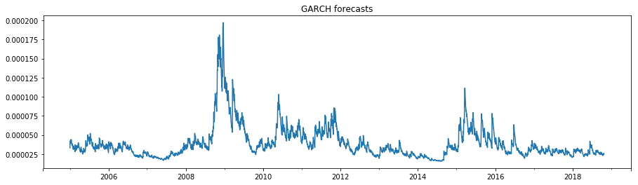

```python
gpred.variance.loc['20050101':, 'h.1'].plot(figsize=(15, 4), title='GARCH forecasts')
```

### Risk metrics:

```python
rmpred = returns.ewm(alpha=0.04).var().shift(1).dropna()
```

Please take into account that rolling/exponentially-weighted estimations are turned into prediction just using the last estimated value as prediction (shifting the value one day ahead!).

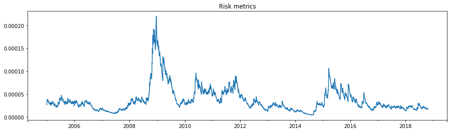

```python
rmpred.loc['20050101':].plot(figsize=(15, 4), title='Risk metrics')
```

### Simple 50-day rolling:

```python
rollpred = returns.rolling(50).var().shift(1).dropna()
```

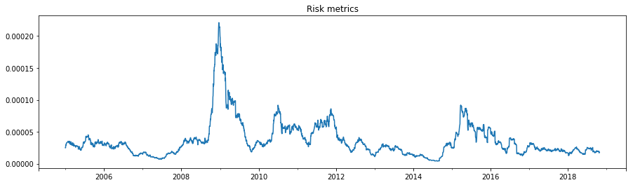

```python
rollpred.loc['20050101':].plot(figsize=(15, 4), title='Risk metrics')
```

### All forecasts:

So the three forecasts are not that different.

```python
forecasts = pd.concat((gpred.variance['h.1'], rmpred, rollpred), axis=1).dropna().loc['20050101':]
forecasts.columns = ['GARCH', 'RiskMetrics EWM', 'Rolling']
```

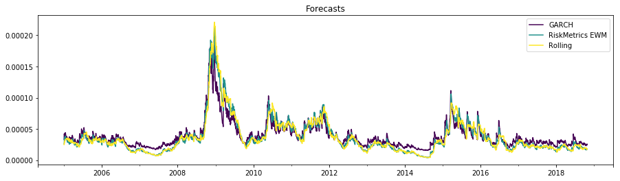

```python
forecasts.plot(figsize=(15, 4), title='Forecasts', cmap='viridis')
```

```python
forecasts.corr()
```

|  | GARCH | RiskMetrics EWM | Rolling |
| --- | --- | --- | --- |
| GARCH | 1.000000 | 0.964736 | 0.925552 |
| RiskMetrics EWM | 0.964736 | 1.000000 | 0.981869 |
| Rolling | 0.925552 | 0.981869 | 1.000000 |

## Comparing out-sample performances:

```python
returns = returns.loc[forecasts.index]
```

```python
returns = returns.values.reshape(-1, 1).T
# We assume constante insample mean for the seek of simplicity:
mus = np.ones((1, returns.shape[1]))*np.mean(returns)
```

```python
# Performances:
for col in forecasts:
    print(col, perf_evaluation(returns, mus, forecasts[col].values.reshape(1, 1, -1) ))
```

```
GARCH 4.727081309137795
RiskMetrics EWM 4.689065958853272
Rolling 4.686979739582831
```

So the best prediction is the one provided by GARCH, whereas the worse one would be the one provided by the rolling volatility estimation!

The returns used for evaluation where the ones of EURUSD in the interval:

```python
forecasts.index[[0, -1]]
```

```
DatetimeIndex(['2005-01-03', '2018-10-25'], dtype='datetime64[ns]', freq=None)
```

# Synthetic:

In order to check if our metric it's actually a good measure of the goodness of our volatility estimator, we can generate several artificial returns, by sampling random samples from a distribution with zero mean an a specific time-varying volatility that will be used as ground truth.

In order to perform the experiment we are going to compare the performance at selecting as optimal the estimation with the least error (in this case we can compute the error because the volatility process it's been created by us!). As estimation methods, we are going to compare volatility estimation using rolling estimations with different rolling windows.

```python
# Funcion to generate synthetic data with a specific characteristic window of variation for the process volatility.
def generate_synthetic(data, window):
    returns = data['EURUSD'].pct_change().dropna()
    ground_truth = returns.rolling(window).var().dropna()
    art_returns = pd.Series(index=ground_truth.index)
    for i in ground_truth.index:
        art_returns.loc[i] = np.sqrt(ground_truth.loc[i])*np.random.randn()
    return ground_truth, art_returns
```

```python
# Generate estimations with rolling windows:
def generate_roll_estimates(rets):
    forecasts = pd.DataFrame()
    for w in np.arange(10, 410, 10):
        forecasts[w] = rets.rolling(w).var().shift(1).dropna()
    forecasts.dropna(inplace=True)
    return forecasts
```

```python
# Evaluate the performances of all the estimates
def evaluate_performance(rets, forecasts):
    rr = rets.loc[forecasts.index]
    rr = rr.values.reshape(-1, 1).T
    mus = np.ones((1, rr.shape[1]))*np.mean(rr)
    # Performances:
    perfs = pd.Series(index=forecasts.columns)
    for col in forecasts:
        perfs.loc[col] = perf_evaluation(rr, mus, forecasts[col].values.reshape(1, 1, -1))
    return perfs
```

```python
# Computing estimation error in our estimates:
def compute_errors(forecasts, ground_truth, rets):
    vol_error = (forecasts - np.tile(ground_truth.values.reshape(-1, 1), (1, forecasts.shape[1]))).abs().mean()
    pred_abs_val = np.sqrt(forecasts)*np.sqrt(2/np.pi)
    absval = np.tile(rets.abs().values.reshape(-1, 1), (1, forecasts.shape[1]))
    abs_error = (pred_abs_val - absval).abs().mean()
    return vol_error, abs_error
```

```python
# Plotting loglikelihood vs volatility estimation error:
def plot_perf(perf, error, term):
    ax = perf.rename('Loglikelihood').to_frame().plot(c='g')
    ax.axvline(perf.idxmax(), c='g' )
    error.rename('Volatility estim. error').to_frame().plot(c='r', secondary_y=True, ax=ax)
    ax.axvline(error.idxmin(), c='r' )
    ax.set_title(term+'-varying volatility')
```

```python
gt, ar = generate_synthetic(data, 261)
re = generate_roll_estimates(ar)
pe = evaluate_performance(ar.loc[re.index], re)
ve_e, ae_e = compute_errors(re, gt.loc[re.index], ar.loc[re.index])
```

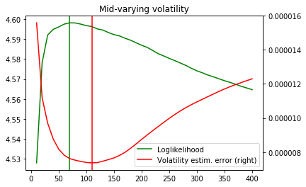

```python
plot_perf(pe, ve_e, 'Mid')
```

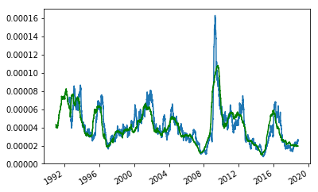

```python
ax = re[pe.idxmax()].plot()
gt.plot(ax=ax, c='g')
```

In this first case, the estimation matches more or less true volatility of the synthetic data generating process.

```python
gt, ar = generate_synthetic(data, 21)
re = generate_roll_estimates(ar)
pe = evaluate_performance(ar.loc[re.index], re)
ve_e, ae_e = compute_errors(re, gt.loc[re.index], ar.loc[re.index])
```

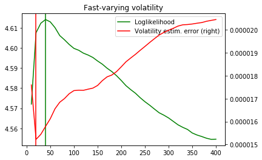

```python
plot_perf(pe, ve_e, 'Fast')
```

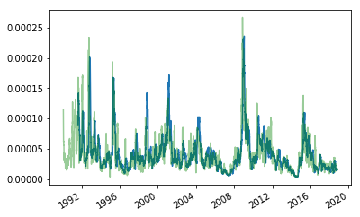

```python
ax = re[pe.idxmax()].plot()
gt.plot(ax=ax, c='g', alpha=.4)
```

In this second case, the best estimation it's actually pretty close to the true one.

```python
gt, ar = generate_synthetic(data, 1000)
re = generate_roll_estimates(ar)
pe = evaluate_performance(ar.loc[re.index], re)
ve_e, ae_e = compute_errors(re, gt.loc[re.index], ar.loc[re.index])
```

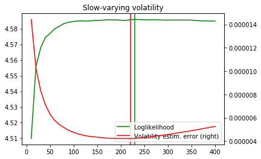

```python
plot_perf(pe, ve_e, 'Slow')
```

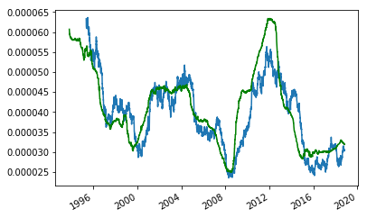

```python
ax = re[pe.idxmax()].plot()
gt.plot(ax=ax, c='g')
```

This last case it's the worst one.

Anyway, it's clear that the likelihood we have defined is pretty good in ranking the best/worst estimations of the volatility, and what's more, this general metric it's also a good choice for evaluating the estimation of full covariance matrices.

# Multivariate example:

In order to test the multivariate version, let's compare the performance of three covariance predictions:

1. Constant sample covariance.
2. Risk metrics exponentially weighted covariance matrix.
3. Rolling 50-days covariance estimation.

As sample data, we are going to use three series: EURUSD, EuroStoxx and S&P500.

```python
returns = data[['EURUSD', 'S&P 500', 'EuroStoxx 50']].pct_change().dropna()
```

### Fix covariance:

As in the prior example, we estimate the fixed sample covariance as the covariance up to 2005, and use the remaining data for evaluation.

```python
fixcov = returns.loc[:'20050101'].cov()
```

We have to conform the static covariance into a tensor with equal covariance for everyday:

```python
fixcov = np.tile(fixcov.values.reshape(3, 3, -1), (1, 1, returns.loc['20050101':].shape[0]))
```

```python
fixcov.shape
```

```
(3, 3, 3604)
```

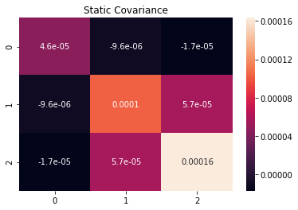

```python
sns.heatmap(fixcov[:, :, 0], annot=True)
ax = plt.gca()
ax.set_title('Static Covariance');
```

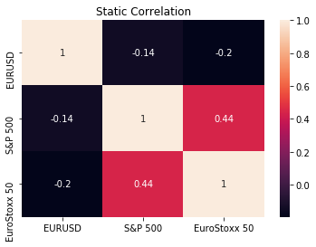

```python
sns.heatmap(returns.loc[:'20050101'].corr(), annot=True)
ax = plt.gca()
ax.set_title('Static Correlation');
```

### Risk metrics:

```python
rmcov = returns.ewm(alpha=0.04).cov().dropna().unstack().shift(1).loc['20050101':]
```

```python
rmcov = rmcov.sort_index(axis=1).dropna().values.T.reshape(3, 3, -1)
```

Dynamical covariances are tensors of size dxdxn where d is 3 in this case (number of variables, dimensionality), and n is the number of timesteps:

```python
rmcov.shape
```

```
(3, 3, 3604)
```

This is the estimated variance for S&P 500:

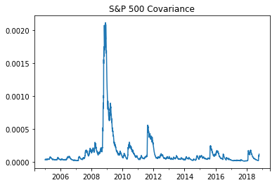

```python
pd.Series(rmcov[2, 2, :], index=returns.loc['20050101':].index).plot(title='S&P 500 Covariance')
```

This is the estimated covvariance EURUSD-EuroStoxx 500:

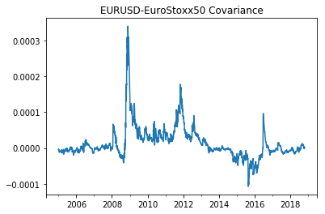

```python
pd.Series(rmcov[0, 1, :], index=returns.loc['20050101':].index).plot(title='EURUSD-EuroStoxx50 Covariance')
```

### Rolling 50-days estimation:

```python
rollcov = returns.rolling(50).cov().dropna().unstack().shift(1).loc['20050101':]
rollcov = rollcov.sort_index(axis=1).dropna().values.T.reshape(3, 3, -1)
rollcov.shape
```

```
(3, 3, 3604)
```

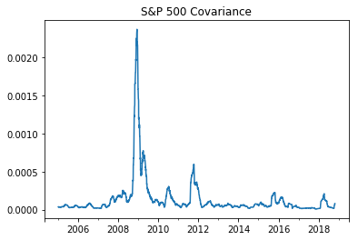

```python
pd.Series(rollcov[2, 2, :], index=returns.loc['20050101':].index).plot(title='S&P 500 Covariance')
```

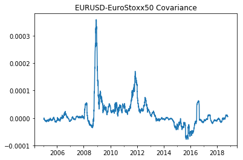

```python
pd.Series(rollcov[0, 1, :], index=returns.loc['20050101':].index).plot(title='EURUSD-EuroStoxx50 Covariance')
```

### Evaluating outsample performance:

Just as easy as it was before, we can now perform an outsample evaluation of our three models:

```python
# Input preparation:
returns = returns.loc['20050101':].values.T
mus = np.tile(np.mean(returns, axis=1).reshape(-1, 1), (1, returns.shape[1]))
forecasts = {}
forecasts['Const'], forecasts['RiskMetrics EWM'], forecasts['Rolling']  = fixcov, rmcov, rollcov
```

```python
# Performances:
for col in forecasts:
    print(col, perf_evaluation(returns, mus, forecasts[col]))
```

```
Const 4.162206850896358
RiskMetrics EWM 4.206980349770926
Rolling 4.174199318992006
```

The worst performing model is the constant one, and the best performing one is the exponentially weighted.

# Conclusions:

1. We propose to use multivariate normal loglikelihood in order to evaluate one-day ahead predictions of the covariance matrix.
2. This outsample metric it's a well-defined and justified metric to compare all kind of models that generate predictions of the covariance matrix.
3. The metric it's useful for the univariate and for the multivariate case and we essentially avoid choosing another estimation of the covariance in the next time step as ground truth for our models.

IMO we could use this metric and that way we could close all the pending issues related with covariance estimations and performance evaluation.